# Continuous Integration Smell Report

Wed Aug 15 11:20:37 2018

### Project: codecentric/spring-boot-admin

### Slow builds

### Broken release branch

### Skip failed tests

### Aged branches

## Slow builds

### ↗ Uptrend -

### During the last 90 days, your build duration is increasing of 21.89%

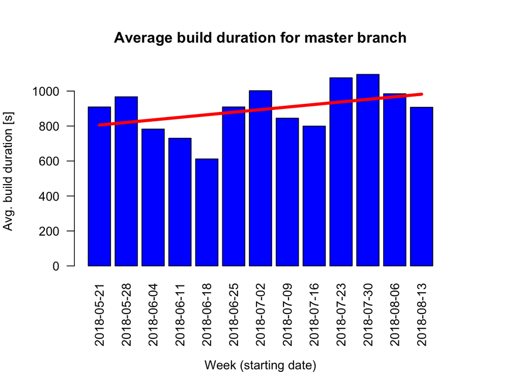

## Broken release branch

In the last 90 days, your master branch was broken 36 times and  
it took on average 14.8 hours to fix it again.

↘ Downtrend:

Over the last 90 days, the number of broken release  
builds decreased by 93.1%.

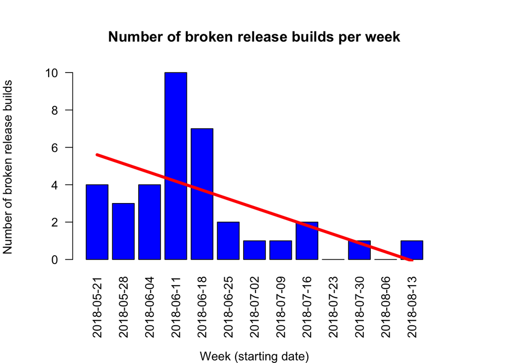

## Skip failed tests

### No skip test warnings found!

## Aged branches

##### Issues found for branch: 1.4.x

- High severity: In your project, branches are typically synced with master every 0s. However, branch 1.4.x has last synced with master on 2018-01-01 17:54:10. and branch master has commits that are 11572568s (~19.13 weeks) newer than that.
- High severity: Your latest commits were performed on branch 2.0.x on 2018-08-09 05:35:35. However, your last changes on branch 1.4.x happened 18963685s (~31.36 weeks) ago, and have not been merged yet. In your project, you typically merge branches within 5204741s (~8.61 weeks).
- High severity: In your project, branches do not deviate for more than 5680024s (~9.39 weeks). However, you are working on branch 1.4.x since 19074070s (~31.54 weeks) without synchronization.

##### Issues found for branch: 1.5.7

- High severity: In your project, branches are typically synced with master every 0s. However, branch 1.5.7 has last synced with master on 2018-01-27 15:00:32. and branch master has commits that are 9336586s (~15.44 weeks) newer than that.
- High severity: Your latest commits were performed on branch 2.0.x on 2018-08-09 05:35:35. However, your last changes on branch 1.5.7 happened 16723784s (~27.65 weeks) ago, and have not been merged yet. In your project, you typically merge branches within 5204741s (~8.61 weeks).
- High severity: In your project, branches do not deviate for more than 5680024s (~9.39 weeks). However, you are working on branch 1.5.7 since 16838088s (~27.84 weeks) without synchronization.
- High severity: You have been working on 1.5.7 for 3919s (~1.09 hours).Your feature branches are typically open for 0s.

##### Issues found for branch: 1.5.x

- High severity: In your project, branches are typically synced with master every 0s. However, branch 1.5.x has last synced with master on 2018-02-01 06:58:00. and branch master has commits that are 8933538s (~14.77 weeks) newer than that.
- High severity: In your project, branches do not deviate for more than 5680024s (~9.39 weeks). However, you are working on branch 1.5.x since 16435040s (~27.17 weeks) without synchronization.
- High severity: You have been working on 1.5.x for 15493081s (~25.62 weeks).Your feature branches are typically open for 0s.

##### Issues found for branch: 2.0.2

- High severity: You have been working on 2.0.2 for 38908s (~10.81 hours).Your feature branches are typically open for 0s.

##### Issues found for branch: bugfix/actuator_path

- High severity: You have been working on bugfix/actuator_path for 87426s (~1.01 days).Your feature branches are typically open for 0s.

##### Issues found for branch: feature/customizable_header

- High severity: You have been working on feature/customizable_header for 1101959s (~1.82 weeks).Your feature branches are typically open for 0s.

##### Issues found for branch: pr-613

- High severity: In your project, branches are typically synced with master every 0s. However, branch pr-613 has last synced with master on 2018-01-01 17:52:44. and branch master has commits that are 11572654s (~19.13 weeks) newer than that.
- High severity: Your latest commits were performed on branch 2.0.x on 2018-08-09 05:35:35. However, your last changes on branch pr-613 happened 18963771s (~31.36 weeks) ago, and have not been merged yet. In your project, you typically merge branches within 5204741s (~8.61 weeks).
- High severity: In your project, branches do not deviate for more than 5680024s (~9.39 weeks). However, you are working on branch pr-613 since 19074156s (~31.54 weeks) without synchronization.

##### Tip: Frequently synchronized branches are easier to integrate.

##### Tip: Break features into smaller tasks to finish them faster.